# What Makes a Shot Dangerous in the PLL?

An Exploratory Analysis of Premier Lacrosse League Shot Data

Author

Lauren Hall

## Introduction

What separates a goal from a save in professional lacrosse? This project investigates shot quality in the Premier Lacrosse League using two datasets: shot-level tracking data from the 2019–2021 PLL seasons, and player-level statistics from 2023–2026. By examining where shots come from, who is taking them, and what predicts a goal, we can begin to build a picture of what makes a shot truly dangerous — and ultimately, which players are the most efficient finishers in the league.

## The Data

Shot-level tracking data from the PLL, with one row per shot attempt. Variables include:

- `X`, `Y` — pixel coordinates of the shot location on a field image
- `Result` — shot outcome: GOAL, OFF (off target), MESSY SAVE, CLEAN SAVE, BLOCKED, or PIPE (hit the post)
- `Assisted` — whether the shot was Assisted or Unassisted
- `Goalie` — the goalie who faced the shot
- `Player` — the shooter’s name
- `Team` — PLL team
- `Year` — season year (2019, 2020, or 2021)
- `College` — shooter’s college, joined from PLL draft history
- `Position` — shooter’s position, joined from 2023–2026 player stats

**stats** (1,000 rows | 2023–2026)

Player-level statistics across four PLL regular seasons. Variables include per-game averages for goals, assists, shots, shooting percentage, 2-point attempts, turnovers, groundballs, faceoffs, saves, and power play stats. Note that percentage columns (`Shooting %`, `Save %`, `Faceoff %`) appear as blank strings rather than true NAs for players who never attempted those actions — these are treated as missing when converting to numeric.

```r
library(tidyverse)
library(ggplot2)
library(readr)
library(sportyR)

shots <- read_csv("~/SportsAnalytics/PLL_ShotData_withCollege.csv")
stats <- read_csv("~/SportsAnalytics/PLL_Stats_2023_2026.csv")

GOAL_X <- 1250
GOAL_Y <- 1600

# Join position from stats data
player_position <- stats %>%
  select(Name, Position) %>%
  distinct()

shots <- shots %>%
  left_join(player_position, by = c("Player" = "Name"))

# Engineer variables
shots <- shots %>%
  mutate(
    is_goal     = Result == "GOAL",
    is_assisted = Assisted == "Assisted",
    x_yards     = (X - 970) / 38,
    y_yards     = -1 * (Y - 733) / 38,
    dist_yards  = sqrt((X - GOAL_X)^2 + (Y - GOAL_Y)^2) / 15,
    shot_angle  = 2 * atan2(1, dist_yards) * (180 / pi)
  )
```

## Missing Values

```r
# NAs by column — shots
colSums(is.na(shots))
```

```
          Y           X      Result    Assisted      Goalie      Player
          0           0           2           0           0           0
       Team        Year     College    Position     is_goal is_assisted
          0           0           0        2835           2           0
    x_yards     y_yards  dist_yards  shot_angle
          0           0           0           0
```

```r
# NAs by column — stats
colSums(is.na(stats))
```

```
                    Name                   Season               First Name
                       0                        0                        0
               Last Name                 Position                   Jersey
                       0                        0                       26
                    Team             Games Played                   Points
                       0                        0                        0
          Scoring Points              Total Goals                1Pt Goals
                       0                        0                        0
               2Pt Goals                  Assists                    Shots
                       0                        0                        0
              Shooting %            Shots On Goal          Shots On Goal %
                    1000                        0                     1000
               2Pt Shots              2Pt Shots %        2Pt Shots On Goal
                       0                     1000                        0
     2Pt Shots On Goal %                Turnovers         Caused Turnovers
                    1000                        0                        0
             Groundballs                  Touches                   Passes
                       0                        0                        0
               Faceoff %             Faceoffs Won            Faceoffs Lost
                    1000                        0                        0
                Faceoffs   Scores Against Average                    Saves
                       0                        0                        0
                  Save %              Clean Saves             Clean Save %
                    1000                        0                     1000
          Scores Against        2Pt Goals Against                Penalties
                       0                        0                        0
  Penalties (in minutes)         Power Play Goals         Power Play Shots
                       0                        0                        0
Power Play Goals Against       Short Handed Goals       Short Handed Shots
                       0                        0                        0
        Unassisted Goals           Assisted Goals
                       0                        0
```

```r
# College coverage
shots %>%
  count(College) %>%
  arrange(desc(n))
```

```
# A tibble: 54 × 2
   College            n
   <chr>          <int>
 1 Unknown          945
 2 Maryland         904
 3 Duke             715
 4 Notre Dame       584
 5 Johns Hopkins    555
 6 Princeton        452
 7 North Carolina   356
 8 Cornell          318
 9 Albany           299
10 Rutgers          257
# ℹ 44 more rows
```

```r
# Position coverage
shots %>%
  count(Position) %>%
  arrange(desc(n))
```

```
# A tibble: 8 × 2
  Position     n
  <chr>    <int>
1 <NA>      2835
2 A         2268
3 M         2228
4 SSDM       320
5 LSM        179
6 D          100
7 FO          85
8 G            4
```

The `shots` dataset has no missing values in its core columns. Two engineered variables (`is_goal`, `Result`) have 2 NAs from rows with no recorded result. The `College` column has ~12% “Unknown” entries for players not found in draft history, and ~2% “Canadian (No College)” for box lacrosse imports. The `Position` column has 2,835 NAs (~35%) because the shots data covers 2019–2021 while position data comes from 2023–2026 rosters — not every player could be matched across eras.

In the `stats` dataset, percentage columns (`Shooting %`, `Save %`, `Faceoff %`) show 1,000 NAs — meaning every row is missing. These are stored as empty strings, not numeric values, and need to be converted before use. All other counting stats are present for every player.

## What Does a Typical Shot Look Like?

Before asking what makes a shot dangerous, it helps to understand the baseline. The chart below shows how shot outcomes are distributed across all three seasons.

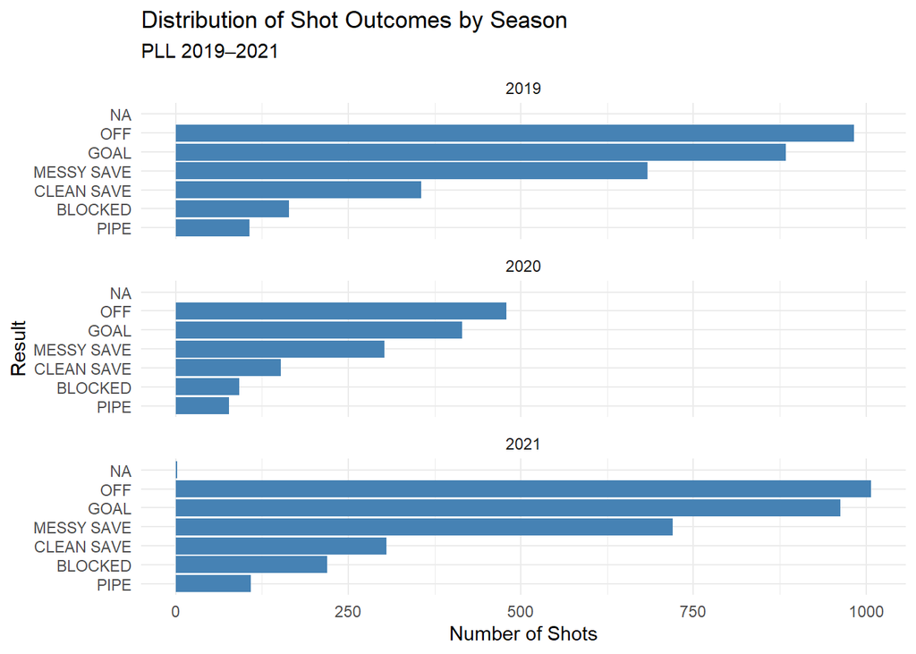

```r
result_counts <- shots %>%
  count(Year, Result)

ggplot(result_counts, aes(x = reorder(Result, n), y = n)) +
  geom_col(fill = "steelblue") +
  coord_flip() +
  facet_wrap(~Year, nrow = 3) +
  labs(
    title    = "Distribution of Shot Outcomes by Season",
    subtitle = "PLL 2019–2021",
    x        = "Result",
    y        = "Number of Shots"
  ) +
  theme_minimal()
```

## Does Distance Matter?

The most intuitive hypothesis in shot quality is that closer shots are more dangerous. The chart below tests this directly by showing goal conversion rate at each distance range.

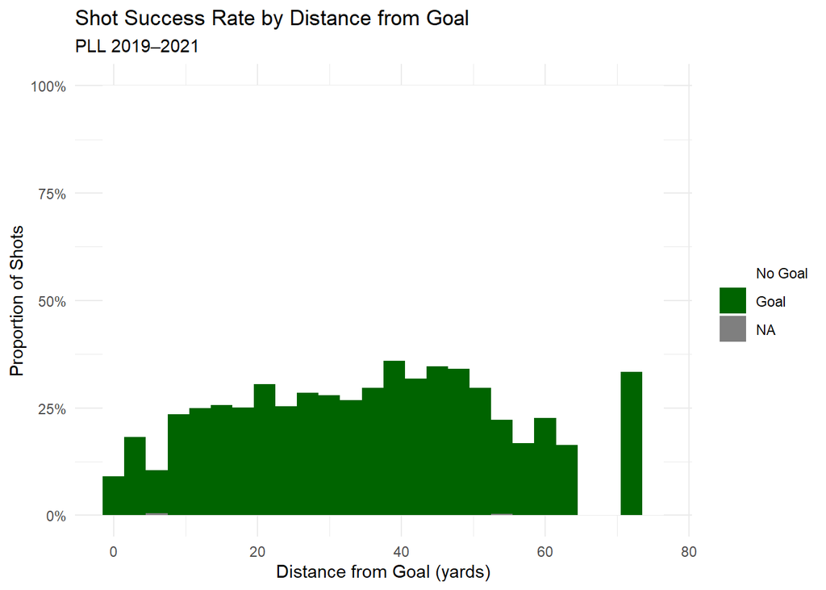

```r
shots %>%
  select(is_goal, dist_yards, shot_angle) %>%
  filter(dist_yards < 75) %>%
  ggplot(aes(x = dist_yards, fill = is_goal)) +
  geom_histogram(binwidth = 3, position = "fill") +
  scale_y_continuous(labels = scales::percent) +
  scale_fill_manual(values = c("FALSE" = "white", "TRUE" = "darkgreen"),
                    labels = c("FALSE" = "No Goal", "TRUE" = "Goal")) +
  labs(
    title = "Shot Success Rate by Distance from Goal",
    subtitle = "PLL 2019–2021",
    x     = "Distance from Goal (yards)",
    y     = "Proportion of Shots",
    fill  = NULL
  ) +
  theme_minimal()
```

## Does Position Tell Us Anything?

If distance alone doesn’t predict goals, position might explain *why* — different positions shoot from different areas of the field by design.

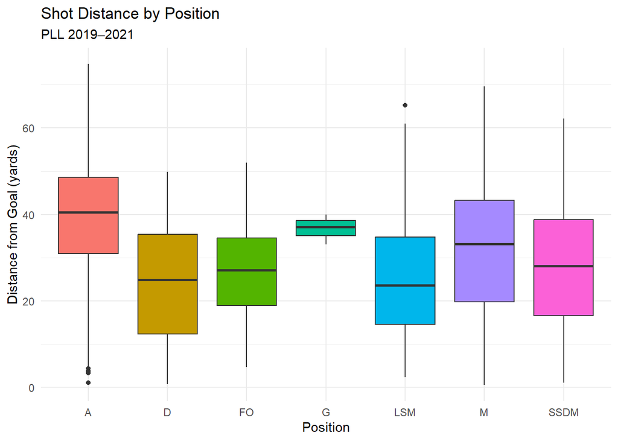

```r
shots %>%
  filter(!is.na(Position), dist_yards < 80) %>%
  ggplot(aes(x = Position, y = dist_yards, fill = Position)) +
  geom_boxplot(show.legend = FALSE) +
  labs(
    title    = "Shot Distance by Position",
    subtitle = "PLL 2019–2021",
    x        = "Position",
    y        = "Distance from Goal (yards)"
  ) +
  theme_minimal()
```

## Building an Expected Goals Model

Armed with distance, angle, and assist data, we can now build a logistic regression model — the same framework used by the PLL’s own analytics team — to estimate the probability that any given shot results in a goal. This gives us an “Expected Goals” (xG) value per shot.

```r
shots_clean <- shots %>%
  filter(!is.na(dist_yards), !is.na(shot_angle), !is.na(is_assisted))

xg_model <- glm(is_goal ~ dist_yards + shot_angle + is_assisted,
                data = shots_clean,
                family = binomial)

summary(xg_model)
```

```
Call:
glm(formula = is_goal ~ dist_yards + shot_angle + is_assisted,
    family = binomial, data = shots_clean)

Coefficients:
                 Estimate Std. Error z value Pr(>|z|)
(Intercept)     -0.933939   0.126825  -7.364 1.78e-13 ***
dist_yards      -0.001339   0.002555  -0.524      0.6
shot_angle      -0.037902   0.009294  -4.078 4.54e-05 ***
is_assistedTRUE  0.437846   0.050123   8.735  < 2e-16 ***
---
Signif. codes:  0 '***' 0.001 '**' 0.01 '*' 0.05 '.' 0.1 ' ' 1

(Dispersion parameter for binomial family taken to be 1)

    Null deviance: 9539.8  on 8016  degrees of freedom
Residual deviance: 9429.5  on 8013  degrees of freedom
  (2 observations deleted due to missingness)
AIC: 9437.5

Number of Fisher Scoring iterations: 4
```

```r
shots_clean$xG <- predict(xg_model, newdata = shots_clean, type = "response")
```

The model results are striking. **Distance is not statistically significant** (p = 0.60) — once you account for angle and whether a shot was assisted, raw distance does not predict whether a shot goes in. By contrast, **shot angle** (p < 0.001) and **whether the shot was assisted** (p < 0.001) are both highly significant predictors.

This is the core finding: in the PLL, shot quality is driven by *where* you’re shooting from relative to the cage, and *how* you got the ball — not simply how far away you are.

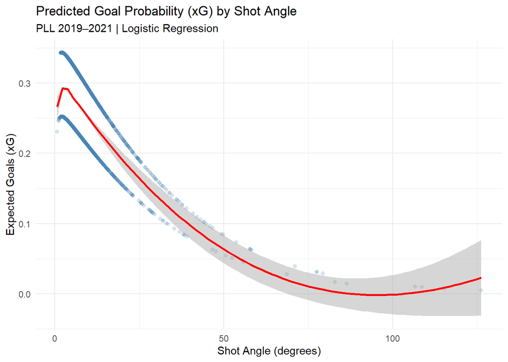

```r
ggplot(shots_clean, aes(x = shot_angle, y = xG)) +
  geom_point(alpha = 0.2, color = "steelblue") +
  geom_smooth(method = "loess", color = "red") +
  labs(
    title    = "Predicted Goal Probability (xG) by Shot Angle",
    subtitle = "PLL 2019–2021 | Logistic Regression",
    x        = "Shot Angle (degrees)",
    y        = "Expected Goals (xG)"
  ) +
  theme_minimal()
```

## Visualizing Shot Locations

The xG model tells us what predicts goals — but where are these shots actually coming from on the field?

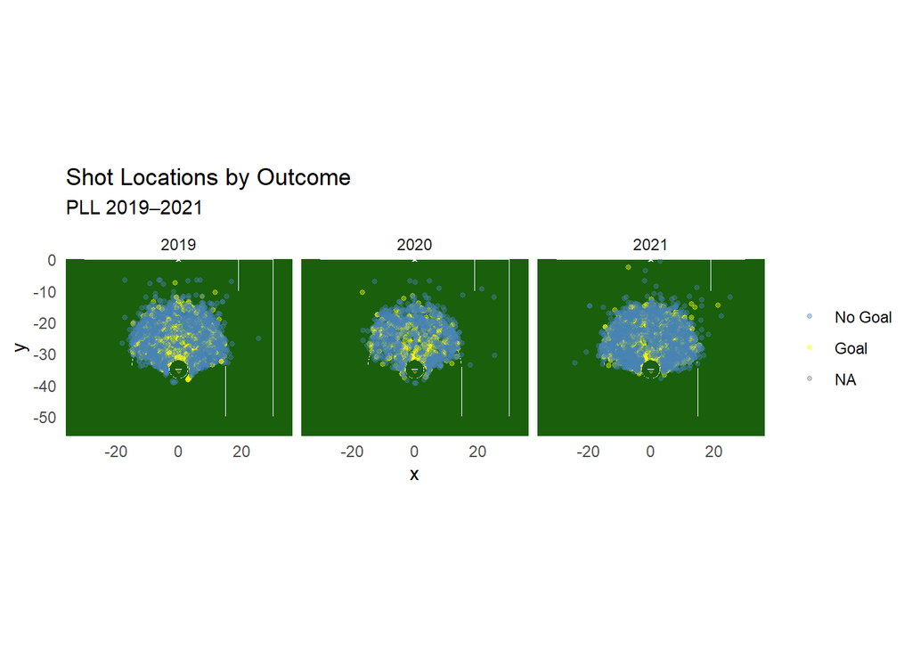

```r
shots <- shots %>%
  mutate(
    x_yards_fixed = (X - 970) / 38,
    y_yards_fixed = (Y - 733) / 38
  )

shots_rotated <- shots %>%
  mutate(
    x = y_yards_fixed - 39.5,
    y = x_yards_fixed - .98
  ) %>%
  select(x, y) %>%
  rotate_coords(angle = 90)

shots <- shots %>%
  mutate(
    x_plot = shots_rotated$x,
    y_plot = shots_rotated$y
  )

geom_lacrosse(league = "PLL", display_range = "offense", rotation = -90) +
  geom_point(data = shots, aes(x = x_plot, y = y_plot, color = is_goal),
             alpha = 0.4, size = 1) +
  facet_wrap(~Year, nrow = 1) +
  scale_color_manual(values = c("FALSE" = "steelblue", "TRUE" = "yellow"),
                     labels = c("FALSE" = "No Goal", "TRUE" = "Goal")) +
  labs(
    title    = "Shot Locations by Outcome",
    subtitle = "PLL 2019–2021",
    color    = NULL
  ) +
  theme_minimal()
```

## Who Converts the Most?

Our model tells us what makes a shot dangerous. But which players are best at converting those opportunities — and do they outperform what their shot selection would predict?

[figure not shown]

```r
efficiency <- stats %>%
  mutate(
    shots_total = as.numeric(Shots) * as.numeric(`Games Played`),
    goals_total = as.numeric(`Total Goals`) * as.numeric(`Games Played`)
  ) %>%
  group_by(Name) %>%
  summarise(
    total_shots = sum(shots_total, na.rm = TRUE),
    total_goals = sum(goals_total, na.rm = TRUE)
  ) %>%
  filter(total_shots >= 50) %>%
  mutate(goals_per_shot = total_goals / total_shots) %>%
  slice_max(goals_per_shot, n = 15)

ggplot(efficiency, aes(x = reorder(Name, goals_per_shot), y = goals_per_shot)) +
  geom_col(fill = "steelblue") +
  coord_flip() +
  labs(
    title    = "Most Efficient Scorers in the PLL",
    subtitle = "Goals per Shot | Min. 50 shots | 2023–2026",
    x        = NULL,
    y        = "Goals per Shot"
  ) +
  theme_minimal()
```

The most efficient scorers in the PLL are not necessarily the highest-drafted players. **Wes Berg** and **Eric Law** — both Denver Pioneers — lead the list, despite neither being first-round picks. Berg’s efficiency reflects years of box lacrosse development in the NLL, where finishing in tight spaces is essential. Law is a four-time MLL All-Star and MLL Player of the Year (2017) who has consistently outperformed expectations.

Meanwhile, **Connor Shellenberger** (No. 2 overall, 2024) and **Aidan Carroll** (No. 7 overall, 2025) are early-career players already validating their draft slots with elite conversion rates. Several mid-round and undrafted players — Drenner (Towson), Brandau (Yale) — appear alongside them, suggesting that shooting efficiency is a trait that transcends draft position.

# Which Players Outperform Their Metrics?

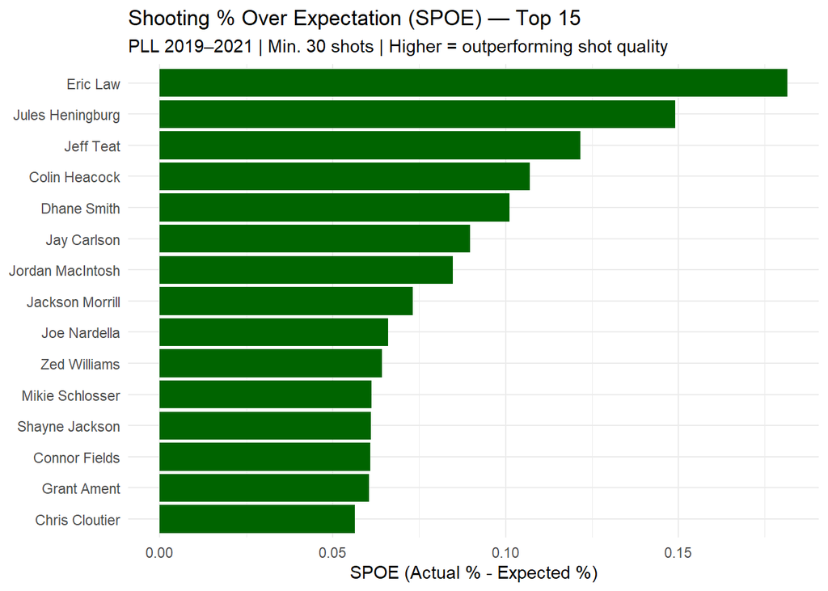

```r
# Calculate SPOE (Shooting Percentage Over Expectation) per player
spoe <- shots_clean %>%
  group_by(Player, College) %>%
  summarise(
    shots  = n(),
    goals  = sum(is_goal),
    avg_xG = mean(xG),
    sh_pct = goals / shots,
    SPOE   = sh_pct - avg_xG,
    .groups = "drop"
  ) %>%
  filter(shots >= 30) %>%
  arrange(desc(SPOE))

# Top 15 overperformers
spoe %>%
  slice_max(SPOE, n = 15) %>%
  ggplot(aes(x = reorder(Player, SPOE), y = SPOE)) +
  geom_col(fill = "darkgreen") +
  coord_flip() +
  labs(
    title    = "Shooting % Over Expectation (SPOE) — Top 15",
    subtitle = "PLL 2019–2021 | Min. 30 shots | Higher = outperforming shot quality",
    x        = NULL,
    y        = "SPOE (Actual % - Expected %)"
  ) +
  theme_minimal()
```

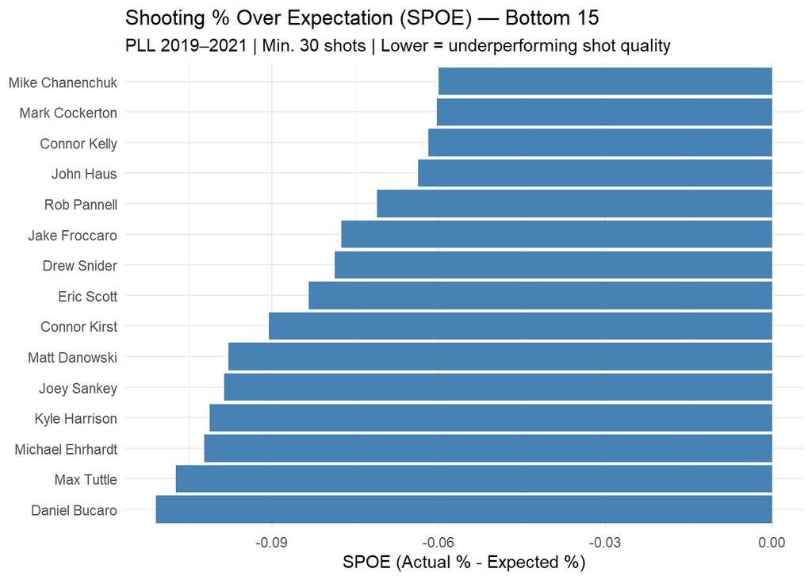

```r
# Bottom 15 underperformers
spoe %>%
  slice_min(SPOE, n = 15) %>%
  ggplot(aes(x = reorder(Player, SPOE), y = SPOE)) +
  geom_col(fill = "steelblue") +
  coord_flip() +
  labs(
    title    = "Shooting % Over Expectation (SPOE) — Bottom 15",
    subtitle = "PLL 2019–2021 | Min. 30 shots | Lower = underperforming shot quality",
    x        = NULL,
    y        = "SPOE (Actual % - Expected %)"
  ) +
  theme_minimal()
```

**SPOE** measures how much a player over- or under-performs relative to the quality of shots they take. A positive SPOE means a player converts at a higher rate than their shot locations and assist rates would predict — they’re finishing better than expected. A negative SPOE means the opposite: they’re getting good looks but not burying them.

This is the true moneyball metric. A player with high shot volume and negative SPOE may be overvalued — they look productive on the scoresheet but are underperforming their opportunities. A player with modest volume but high SPOE is quietly one of the most dangerous finishers in the league, and likely undervalued by teams that only look at raw goals.

**Top performers:** Eric Law leads by a wide margin — he’s converting nearly 19% better than his shot quality predicts, which is remarkable. Jules Heningburg and Jeff Teat round out the top three. Notably, several Canadian players appear in the top 15 (Dhane Smith, Jordan MacIntosh) — this likely reflects their box lacrosse backgrounds, where finishing in tight spaces under pressure is a core skill that translates directly to outperforming xG in field lacrosse.

**Bottom performers:** Daniel Bucaro and Max Tuttle sit at the bottom, converting nearly 10% *worse* than their shot quality predicts. Rob Pannell and Kyle Harrison — both well-known PLL names — also appear here, which is the most interesting finding. These are players who generate high-quality looks but aren’t finishing them at the rate the model expects. From a team-building perspective, that’s a meaningful distinction: they’re not taking bad shots, they’re just not converting the good ones.

**The moneyball angle:** The bottom 15 contains several recognizable, well-compensated players. If teams are evaluating attackers based on raw goal totals or reputation rather than SPOE, they may be systematically overvaluing players who get great looks but underperform — and undervaluing efficient finishers like Eric Law and Jules Heningburg who quietly outperform their opportunities every time they shoot.